# RplotterPkg::create_bar_plot() demos

Rick Dean

12/18/2019

```r
library(ggplot2)
library(dplyr)
library(data.table)
library(forcats)
library(socviz)
library(rlang)
library(grid)
library(gtable)
library(RplotterPkg)
```

# Demos

## 1 Introduction

The following R scripts provides some bar plot examples of [RplotterPkg::create_bar_plot()](https://github.com/deandevl/RplotterPkg).

## 2 Setting just the aes_x aesthetic.

Plotting a bar chart showing counts across a categorical/factor variable. The ggplot2::diamonds dataset has a factor variable named *cut*.

```r
str(ggplot2::diamonds)
## tibble [53,940 x 10] (S3: tbl_df/tbl/data.frame)
##  $ carat  : num [1:53940] 0.23 0.21 0.23 0.29 0.31 0.24 0.24 0.26 0.22 0.23 ...
##  $ cut    : Ord.factor w/ 5 levels "Fair"<"Good"<..: 5 4 2 4 2 3 3 3 1 3 ...
##  $ color  : Ord.factor w/ 7 levels "D"<"E"<"F"<"G"<..: 2 2 2 6 7 7 6 5 2 5 ...
##  $ clarity: Ord.factor w/ 8 levels "I1"<"SI2"<"SI1"<..: 2 3 5 4 2 6 7 3 4 5 ...
##  $ depth  : num [1:53940] 61.5 59.8 56.9 62.4 63.3 62.8 62.3 61.9 65.1 59.4 ...
##  $ table  : num [1:53940] 55 61 65 58 58 57 57 55 61 61 ...
##  $ price  : int [1:53940] 326 326 327 334 335 336 336 337 337 338 ...
##  $ x      : num [1:53940] 3.95 3.89 4.05 4.2 4.34 3.94 3.95 4.07 3.87 4 ...
##  $ y      : num [1:53940] 3.98 3.84 4.07 4.23 4.35 3.96 3.98 4.11 3.78 4.05 ...
##  $ z      : num [1:53940] 2.43 2.31 2.31 2.63 2.75 2.48 2.47 2.53 2.49 2.39 ...
```

Task: Assign the argument *aes_x* to “cut” and display and label its factor level counts with default y axis scaling.

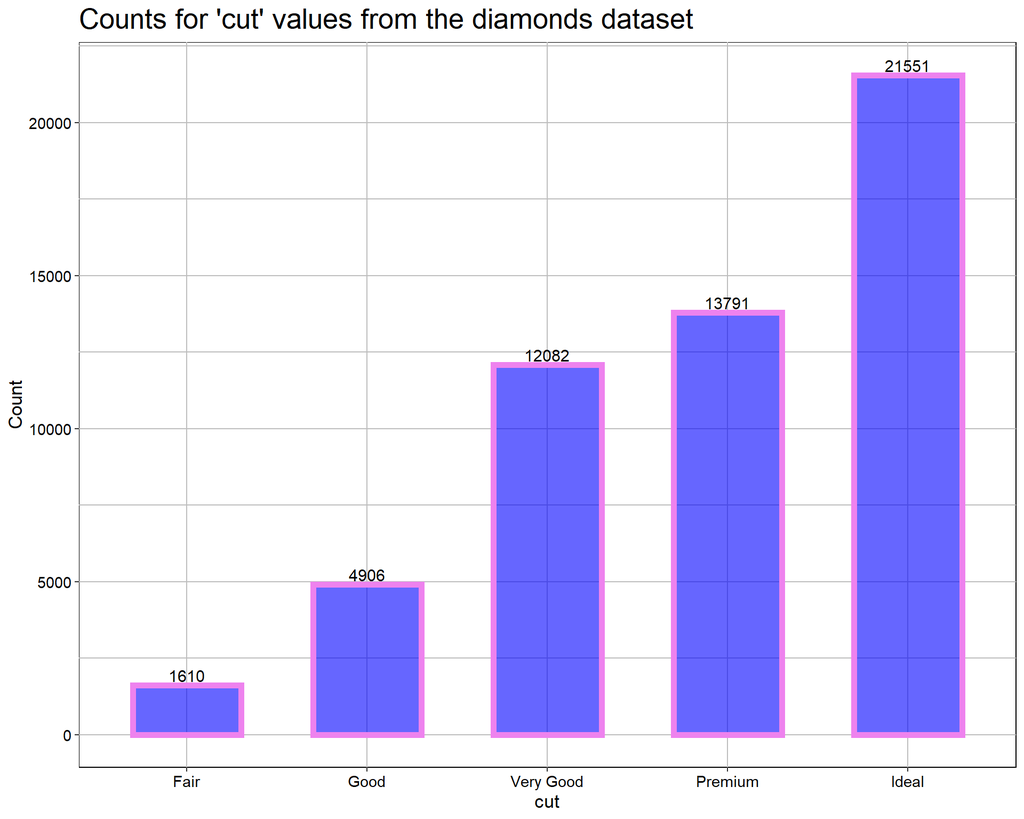

```r
RplotterPkg::create_bar_plot(
  df = ggplot2::diamonds,
  aes_x = "cut",
  title = "Counts for 'cut' values from the diamonds dataset",
  bar_fill = "blue",
  bar_color = "violet",
  bar_size = 2,
  bar_width = 0.6,
  bar_alpha = 0.6,
  rot_y_tic_label = TRUE,
  bar_labels = TRUE
)
```

Task: Continuing with the same *cut* variable, set the y axis limits, breaks, and labels. Also center the title and change the labelling along the x axis.

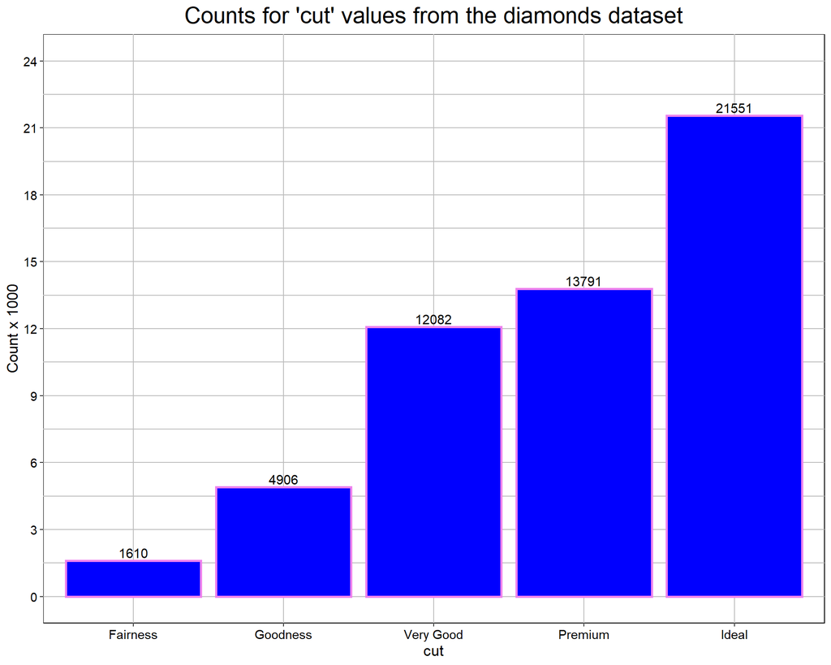

```r
RplotterPkg::create_bar_plot(
  df = ggplot2::diamonds,
  aes_x = "cut",
  title = "Counts for 'cut' values from the diamonds dataset",
  y_title = "Count x 1000",
  bar_fill = "blue",
  bar_color = "violet",
  x_labels = c("Fairness", "Goodness", "Very Good", "Premium", "Ideal"),
  y_limits = c(0, 24000),
  y_major_breaks = seq(from = 0, to = 24000, by = 3000),
  y_labels = c("0", "3", "6", "9", "12", "15", "18", "21", "24"),
  rot_y_tic_label = TRUE,
  center_titles = TRUE,
  bar_labels = TRUE
)
```

## 3 Setting both aes_x aesthetic and aes_y.

By default `create_bar_plot()` displays bars whose heights show the count of categorical variable levels. Instead of counts, we can have bars whose heights reflect a numeric value such as proportions, weights, or some other non-count values.

Task: We are given a dataset with a *name* and *weight* variable which we will reorder from low to high by setting *order_bars* to “asc”. We can create a bar chart by assigning *aes_x* to the categorical variable “name” and *aes_y* to “weight” – the height of the bars will identify with the value of *weight*.

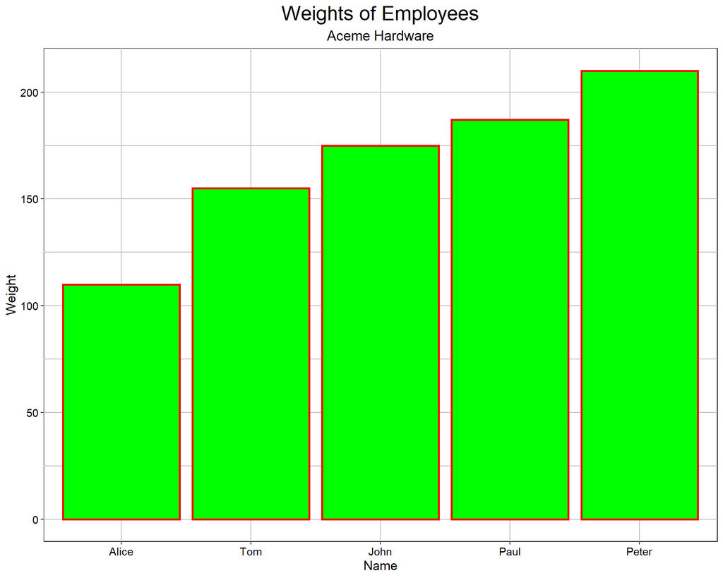

```r
people_weights_df <- data.frame(
  name = c("John", "Alice", "Peter", "Paul", "Tom"),
  weight = c(175, 110, 210, 187, 155)
)

RplotterPkg::create_bar_plot(
  df = people_weights_df,
  aes_x = "name",
  aes_y = "weight",
  title = "Weights of Employees",
  subtitle = "Aceme Hardware",
  x_title = "Name",
  y_title = "Weight",
  bar_fill = "green",
  bar_color = "red",
  rot_y_tic_label = TRUE,
  center_titles = TRUE,
  order_bars = "asc"
)
```

## 4 Setting both aes_x and aes_fill aesthetics.

Assign one x axis categorical variable and obtain its counts across the levels of a second categorical/factor variable.

Task: From the `diamond` dataset we want to see the counts for *cut* across levels of *clarity*. Assign *aes_x* to “cut” and *aes_fill* to “clarity”. In addition assign *position* to “dodge” to position the bars side by side instead of stacked.

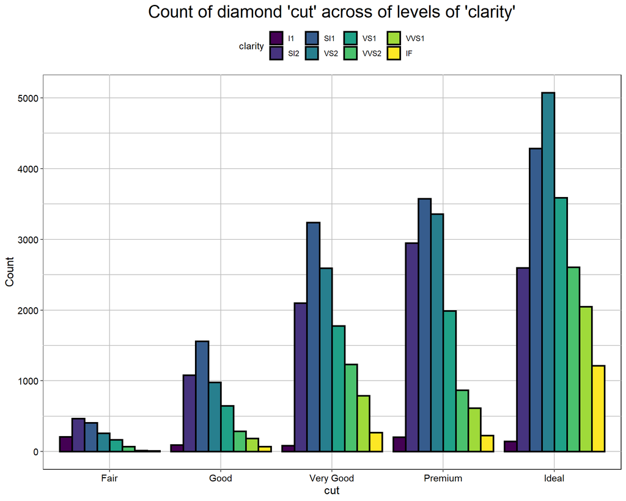

```r
RplotterPkg::create_bar_plot(
  df = ggplot2::diamonds,
  aes_x = "cut",
  title = "Count of diamond 'cut' across of levels of 'clarity'",
  aes_fill = "clarity",
  position = "dodge",
  rot_y_tic_label = TRUE,
  center_titles = TRUE
)
```

In the `socviz::gss_sm` dataset there are two factor variables, *happy* and *religion*.

```r
glimpse(socviz::gss_sm)
```

```
## Rows: 2,867
## Columns: 32
## $ year        <dbl> 2016, 2016, 2016, 2016, 2016, 2016, 2016, 2016, 2016, 2...
## $ id          <dbl> 1, 2, 3, 4, 5, 6, 7, 8, 9, 10, 11, 12, 13, 14, 15, 16, ...
## $ ballot      <labelled> 1, 2, 3, 1, 3, 2, 1, 3, 1, 3, 2, 1, 2, 3, 2, 3, 3,...
## $ age         <dbl> 47, 61, 72, 43, 55, 53, 50, 23, 45, 71, 33, 86, 32, 60,...
## $ childs      <dbl> 3, 0, 2, 4, 2, 2, 2, 3, 3, 4, 5, 4, 3, 5, 7, 2, 6, 5, 0...
## $ sibs        <labelled> 2, 3, 3, 3, 2, 2, 2, 6, 5, 1, 4, 4, 3, 6, 0, 1, 3,...
## $ degree      <fct> Bachelor, High School, Bachelor, High School, Graduate,...
## $ race        <fct> White, White, White, White, White, White, White, Other,...
## $ sex         <fct> Male, Male, Male, Female, Female, Female, Male, Female,...
## $ region      <fct> New England, New England, New England, New England, New...
## $ income16    <fct> $170000 or over, $50000 to 59999, $75000 to $89999, $17...
## $ relig       <fct> None, None, Catholic, Catholic, None, None, None, Catho...
## $ marital     <fct> Married, Never Married, Married, Married, Married, Marr...
```

[output cut: 19 more lines]

Task: Plot the distribution of the different religions across levels of *happy*. Set *palette_colors* to a vector of custom colors to be used in filling the bars. Set the *position* of the bars as side-by-side (i.e. **position = “dodge”**).

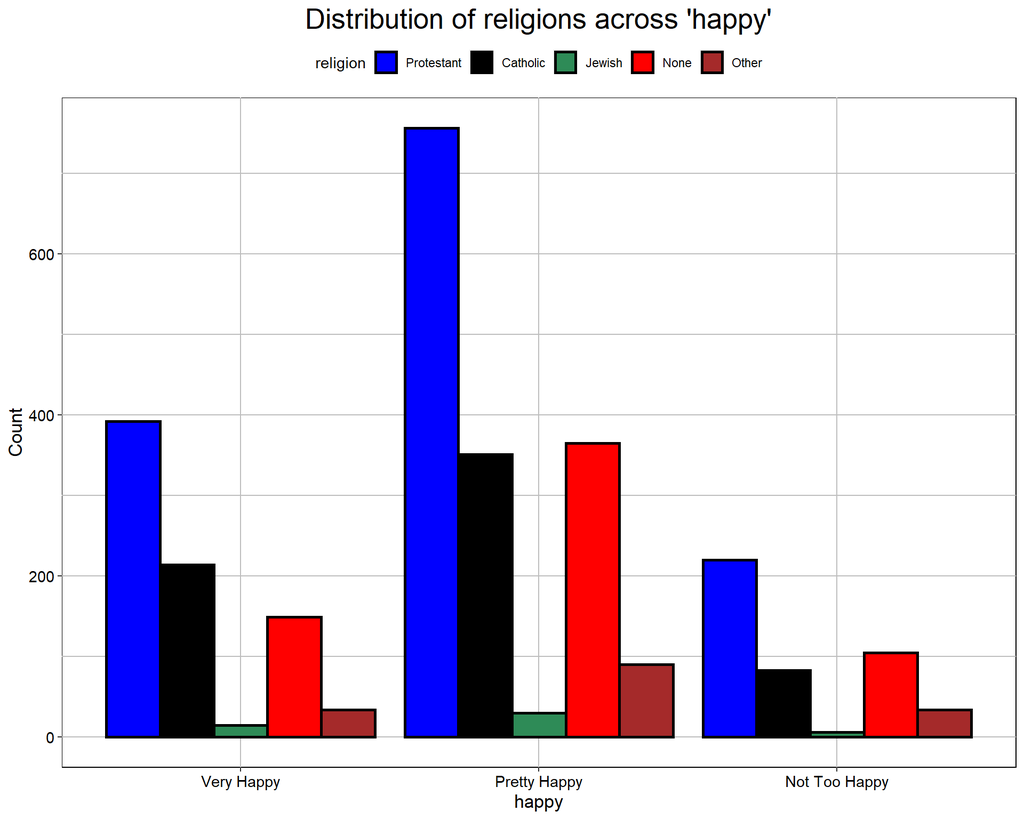

```r
religion_df <- socviz::gss_sm %>% filter(!is.na(religion) & !is.na(happy)) %>% select(happy,religion)
RplotterPkg::create_bar_plot(
  df = religion_df,
  title = "Distribution of religions across 'happy'",
  aes_x = "happy",
  aes_fill = "religion",
  position = "dodge",
  palette_colors = c("blue", "black", "seagreen", "red", "brown"),
  center_titles = TRUE,
  rot_y_tic_label = TRUE
)
```

Task: Find the percentages between Catholic and Protestant across the levels of happy.

```r
religion_df <- socviz::gss_sm %>% filter(!is.na(religion) & !is.na(happy)) %>% select(happy,religion)
religion_percent_happy_df <- religion_df %>%
  group_by(religion, happy) %>%
  rename(Happy = happy) %>%
  summarise(
    n = n()
  ) %>%
  mutate(
    Percent = n/sum(n)
  )
str(religion_percent_happy_df)
## tibble [15 x 4] (S3: grouped_df/tbl_df/tbl/data.frame)
##  $ religion: Factor w/ 5 levels "Protestant","Catholic",..: 1 1 1 2 2 2 3 3 3 4 ...
##  $ Happy   : Factor w/ 3 levels "Very Happy","Pretty Happy",..: 1 2 3 1 2 3 1 2 3 1 ...
##  $ n       : int [1:15] 392 756 220 214 351 83 15 30 6 149 ...
##  $ Percent : num [1:15] 0.287 0.553 0.161 0.33 0.542 ...
##  - attr(*, "groups")= tibble [5 x 2] (S3: tbl_df/tbl/data.frame)
##   ..$ religion: Factor w/ 5 levels "Protestant","Catholic",..: 1 2 3 4 5
##   ..$ .rows   : list<int> [1:5]
##   .. ..$ : int [1:3] 1 2 3
##   .. ..$ : int [1:3] 4 5 6
##   .. ..$ : int [1:3] 7 8 9
##   .. ..$ : int [1:3] 10 11 12
##   .. ..$ : int [1:3] 13 14 15
##   .. ..@ ptype: int(0)
##   ..- attr(*, ".drop")= logi TRUE
```

Task: Plot Catholic vs Protestant across percentage of happy levels. Position the bars as stacked (i.e. **position = “stack”**). Define *x_limits* so that we plot just Catholic and Protestant.

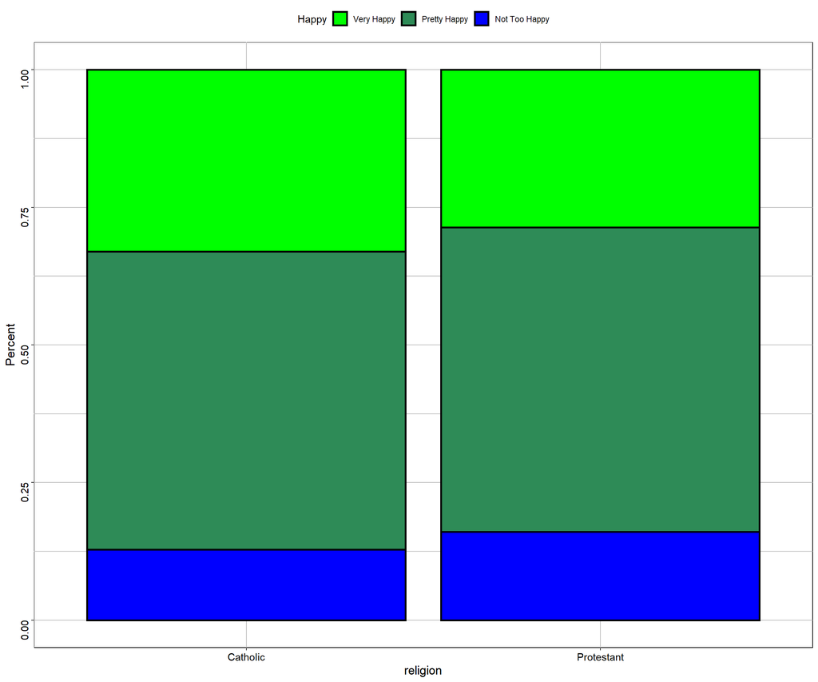

```r
RplotterPkg::create_bar_plot(
  df = religion_percent_happy_df,
  aes_x = "religion",
  aes_y = "Percent",
  y_title = "Percent",
  aes_fill = "Happy",
  position = "stack",
  palette_colors = c("green", "seagreen", "blue"),
  x_limits = c("Catholic", "Protestant")
)
```

## 5 Multi plots of data frame variables.

We want to see the counts of multiple factors from a single data frame.

Task: Plot the level counts of several factor variables from the `socviz::gss_sm` data frame.

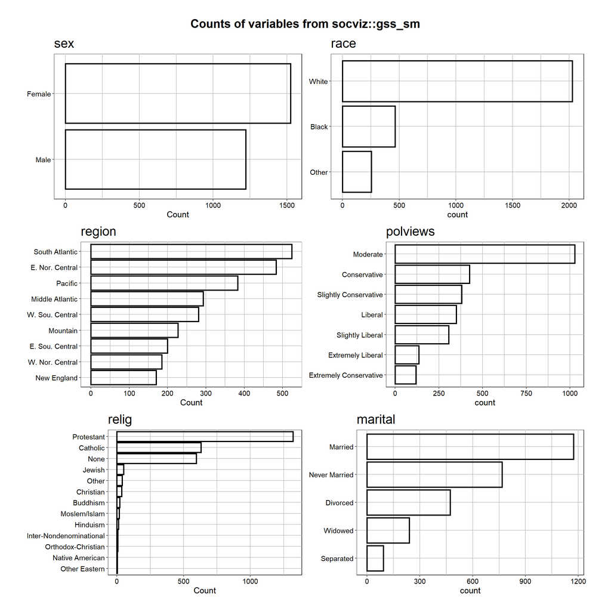

```r
data_df <- socviz::gss_sm %>% filter(!is.na(relig) & !is.na(polviews) & !is.na(marital))

variables_gss_sm_plot <- RplotterPkg::multi_bar_plot(
  df = data_df,
  variables = c("sex", "race", "region", "polviews", "relig", "marital"),
  title = "Counts of variables from socviz::gss_sm",
  col_width = 6,
  rot_y_tic_label = TRUE,
  do_coord_flip = TRUE,
  order_bars = TRUE
)
```

## 6 Multi plots across levels of factor variables.

Task: From `RplotterPkg::multi_bar_plot()` and the `diamond` dataset assign *factor_var* to “clarity” and assign *factor_x* to “cut”. The multi-panelled plot will show counts across levels of *clarity* and *cut*.

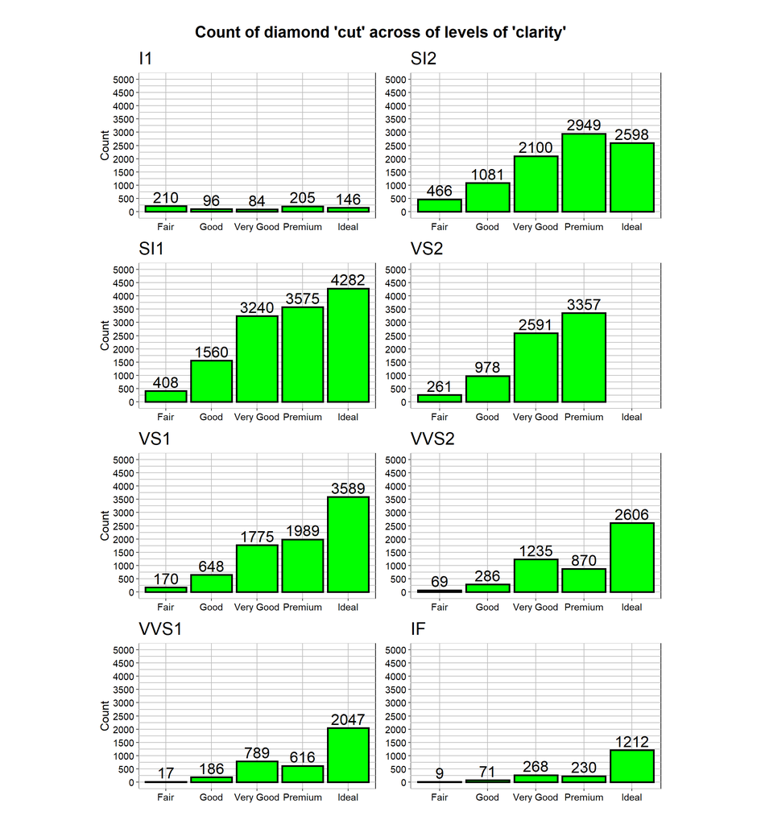

```r
cut_clarity_panels_plot <- RplotterPkg::multi_bar_plot(
  df = ggplot2::diamonds,
  factor_var = "clarity",
  factor_x = "cut",
  title = "Count of diamond 'cut' across of levels of 'clarity'",
  rot_y_tic_label = TRUE,
  bar_color = "black",
  bar_fill = "green",
  y_limits = c(0, 5000),
  y_major_breaks = seq(from =0,to = 5000, by = 500),
  col_width = 4.5,
  row_height = 3,
  bar_labels = TRUE,
  silent_NA_warning = TRUE
)
```

In a similar fashion, instead of counts we want to show a measurement across levels of a pair of factors. For example in the `socviz::gss_sm` dataset find the percent across levels of *religion* and *bigregion*.

Task: Taking the `socviz::gss_sm` dataset find the percent of each level of *religion* across *bigregion*.

```r
percent_religion_df <- socviz::gss_sm %>%
  filter(!is.na(religion)) %>%
  group_by(bigregion, religion) %>%
  summarise(n_relig = n()) %>%  # religion is peeled off; is now grouped by bigregion
  mutate(Percent = n_relig/sum(n_relig) * 100) # sum(n_relig) is the total by bigregion
str(percent_religion_df)
## tibble [20 x 4] (S3: grouped_df/tbl_df/tbl/data.frame)
##  $ bigregion: Factor w/ 4 levels "Northeast","Midwest",..: 1 1 1 1 1 2 2 2 2 2 ...
##  $ religion : Factor w/ 5 levels "Protestant","Catholic",..: 1 2 3 4 5 1 2 3 4 5 ...
##  $ n_relig  : int [1:20] 158 162 27 112 28 325 172 3 157 33 ...
##  $ Percent  : num [1:20] 32.44 33.26 5.54 23 5.75 ...
##  - attr(*, "groups")= tibble [4 x 2] (S3: tbl_df/tbl/data.frame)
##   ..$ bigregion: Factor w/ 4 levels "Northeast","Midwest",..: 1 2 3 4
##   ..$ .rows    : list<int> [1:4]
##   .. ..$ : int [1:5] 1 2 3 4 5
##   .. ..$ : int [1:5] 6 7 8 9 10
##   .. ..$ : int [1:5] 11 12 13 14 15
##   .. ..$ : int [1:5] 16 17 18 19 20
##   .. ..@ ptype: int(0)
##   ..- attr(*, ".drop")= logi TRUE
```

Task: We want to see the bars reflect percentages of religions across *bigregion* in separate bar charts so set *factor_var* to “bigregion”, *factor_x* to “religion” and our measurement *aes_y* to “Percent” in `RplotterPkg::multi_bar_plot()`.

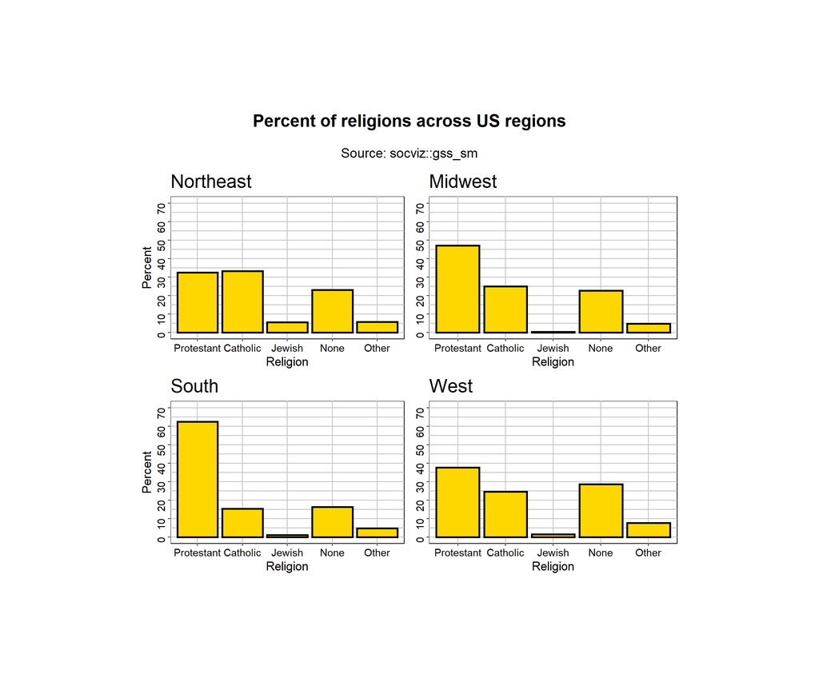

```r
religion_by_region_plot <- RplotterPkg::multi_bar_plot(
  df = percent_religion_df,
  factor_var = "bigregion",
  factor_x = "religion",
  aes_y = "Percent",
  y_limits = c(0,70),
  y_major_breaks = seq(from = 0, to = 70, by = 10),
  bar_fill = "gold",
  bar_color = "black",
  title = "Percent of religions across US regions",
  subtitle = "Source: socviz::gss_sm",
  x_title = "Religion",
  col_width = 4,
  row_height = 3,
  silent_NA_warning = TRUE
)
```

Task: Repeat the above plot but flip the Religion and Percent axis’ by setting *do_coord_flip* to TRUE.

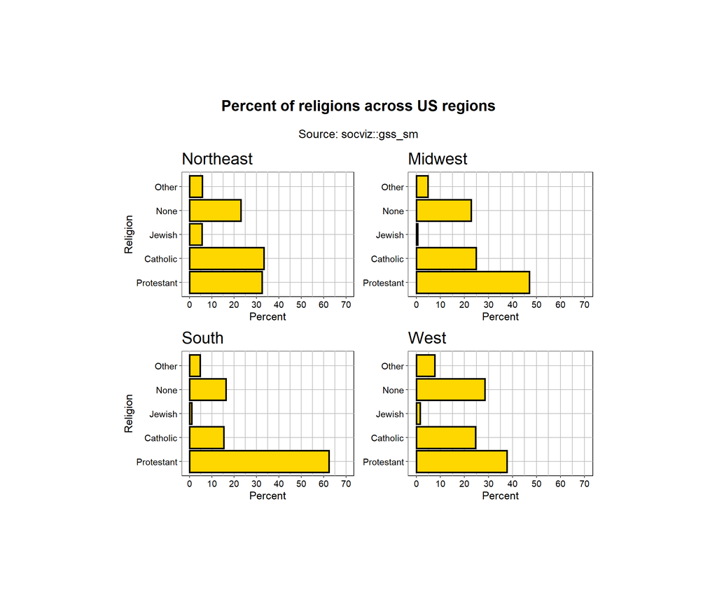

```r
religion_by_region_plot <- RplotterPkg::multi_bar_plot(
  df = percent_religion_df,
  factor_var = "bigregion",
  factor_x = "religion",
  aes_y = "Percent",
  y_limits = c(0,70),
  y_major_breaks = seq(from = 0, to = 70, by = 10),
  bar_fill = "gold",
  bar_color = "black",
  title = "Percent of religions across US regions",
  subtitle = "Source: socviz::gss_sm",
  x_title = "Religion",
  do_coord_flip = TRUE,
  rot_y_tic_label = TRUE,
  col_width = 4,
  row_height = 3,
  silent_NA_warning = TRUE
)
```

Task: From the `socviz::gss_sm` dataset show the distribution of *happy* by *sex* across marital status. Overlap the bars by setting *position* = “identity”.

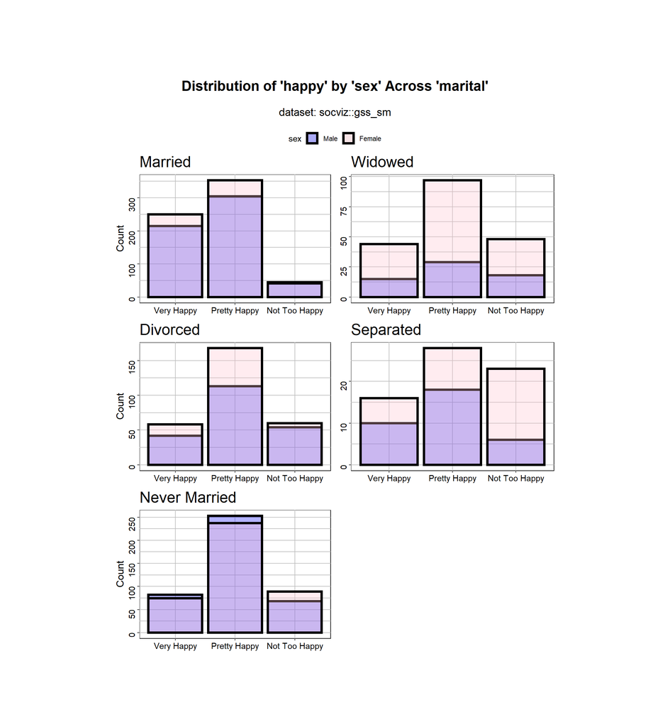

```r
marital_df <- socviz::gss_sm %>%
  filter(!is.na(happy)) %>%
  rename(Happy = happy)
sex_happy_marital_plot <- RplotterPkg::multi_bar_plot(
  df = marital_df,
  factor_var = "marital",
  factor_x = "Happy",
  aes_fill = "sex",
  position = "identity",
  title = "Distribution of 'happy' by 'sex' Across 'marital'",
  subtitle = "dataset: socviz::gss_sm",
  palette_colors = c(Male = "blue", Female = "pink"),
  bar_alpha = 0.3,
  bar_size = 1.5,
  col_width = 4,
  row_height = 3
)
```